# Lab 1.1: Introduction to *R*

July 2023

# Contents

Authors: Martin Morgan, Sonali Arora, Lori Shepherd  
Back: Intro labs

**Objective**: Gain confidence working with base R commands and data structures.

**Lessons learned**:

- Basic data input
- Working with data.frames
- Subsetting, including working with NA values and factors
- Summary statistics
- Visualization using base R and ggplot2

# 1 R

## 1.1 Language and environment for statistical computing and graphics

- Interactive and *interpreted* – convenient and forgiving
- Statistical, e.g. `factor()`, `NA`
- Full-featured programming language
- Extensible
  - *Packages* extend the base langauge
  - CRAN, Bioconductor, github, …
- Coherent, extensive documentation
  - `?factor`
  - `browseVignettes()`

## 1.2 Vector, class, object

- Efficient *vectorized* calculations on ‘atomic’ vectors `logical`, `integer`, `numeric`, `complex`, `character`, `raw`

  ```r
  character_vector <- c("January", "February", "March", "April", "May")
  logical_vector <- c(FALSE, FALSE, TRUE, TRUE, TRUE)
  integer_vector <- 1:5  # c(1, 2, 3, 4, 5)
  ```

- Atomic vectors are building blocks for more complicated *objects*
  - `factor` – enumeration of possible levels

    ```r
    months <- factor(
        character_vector,     # values realized in 'months'
        levels = c(           # possible values
            "January", "February", "March", "April", "May", "June", "July",
            "August", "September", "October", "November", "December"
        )
    )
    ```

  - `matrix` – atomic vector with ‘dim’ attribute

    ```r
    matrix(1:6, nrow = 3)  # n.b., 'column-major' order
    ```

    ```
    ##      [,1] [,2]
    ## [1,]    1    4
    ## [2,]    2    5
    ## [3,]    3    6
    ```

- `data.frame` – list of equal length atomic vectors

  ```r
  data_frame <- data.frame(
      month = months,
      is_spring = logical_vector,
      month_of_year = integer_vector
  )
  ```

- Formal *classes* represent complicated combinations of vectors, e.g., the return value of `lm()`, below

## 1.3 Function, generic, method

- Functions transform inputs to outputs, perhaps with side effects

  ```r
  rnorm(5)
  ```

  ```
  ## [1]  0.3491630 -0.8539779 -0.2094599 -0.4175601  2.1881486
  ```

- Argument matching first by name, then by position
  - Functions may define (some) arguments to have default values

    ```r
    log(1:5)            # default base = exp(1)
    ```

    ```
    ## [1] 0.0000000 0.6931472 1.0986123 1.3862944 1.6094379
    ```

    ```r
    log(1:5, base = 10)
    ```

    ```
    ## [1] 0.0000000 0.3010300 0.4771213 0.6020600 0.6989700
    ```

    ```r
    log(base = 10, 1:5) # named arguments match before unnamed
    ```

    ```
    ## [1] 0.0000000 0.3010300 0.4771213 0.6020600 0.6989700
    ```

- *Generic* functions dispatch to specific *methods* based on class of argument(s), e.g., `print()`.
- Methods are functions that implement specific generics, e.g., `print.factor`; methods are invoked *indirectly*, via the generic.

  ```r
  ?print        # what does the generic 'print()' do?
  ?print.factor # what does the method 'print(x)', when x is a factor, do?
  ```

- Many but not all functions able to manipulate a particular class are methods, e.g., `abline()` used below is a plain-old-function.

## 1.4 Programming

Iteration:

- `lapply()`

  ```r
  args(lapply)
  ```

  ```
  ## function (X, FUN, ...)
  ## NULL
  ```

  - Meaning: for a vector `X` (an atomic vector or `list()`), apply a function `FUN` to each vector element, returning the result as a **l**ist. `...` are additional arguments to `FUN`.
  - `FUN` can be built-in, or a user-defined function

  ```r
  lst <- list(a=1:2, b=2:4)
  lapply(lst, log)      # 'base' argument default; natural log
  ```

  ```
  ## $a
  ## [1] 0.0000000 0.6931472
  ##
  ## $b
  ## [1] 0.6931472 1.0986123 1.3862944
  ```

  ```r
  lapply(lst, log, 10)  # '10' is second argument to 'log()', i.e., log base 10
  ```

  ```
  ## $a
  ## [1] 0.00000 0.30103
  ##
  ## $b
  ## [1] 0.3010300 0.4771213 0.6020600
  ```

  - `sapply()` – like `lapply()`, but simplify the result to a vector, matrix, or array, if possible.
  - `vapply()` – like `sapply()`, but requires that the return type of `FUN` is specified; this can be safer – an error when the result is of an unexpected type.
- `mapply()` (also `Map()`)

  ```r
  args(mapply)
  ```

  ```
  ## function (FUN, ..., MoreArgs = NULL, SIMPLIFY = TRUE, USE.NAMES = TRUE)
  ## NULL
  ```

  - `...` are one or more vectors, recycled to be of the same length. `FUN` is a function that takes as many arguments as there are components of `...`. `mapply` returns the result of applying `FUN` to the elements of the vectors in `...`.

    ```r
    mapply(seq, 1:3, 4:6, SIMPLIFY=FALSE) # seq(1, 4); seq(2, 5); seq(3, 6)
    ```

    ```
    ## [[1]]
    ## [1] 1 2 3 4
    ##
    ## [[2]]
    ## [1] 2 3 4 5
    ##
    ## [[3]]
    ## [1] 3 4 5 6
    ```

  - `apply()`

    ```r
    args(apply)
    ```

    ```
    ## function (X, MARGIN, FUN, ..., simplify = TRUE)
    ## NULL
    ```

  - For a matrix or array `X`, apply `FUN` to each `MARGIN` (dimension, e.g., `MARGIN=1` means apply `FUN` to each row, `MARGIN=2` means apply `FUN` to each column)
- Traditional iteration programming constructs `repeat {}`, `for () {}`
  - Almost always more error-prone, less efficient, and harder to understand than `lapply()` !

Conditional

```r
if (test) {
    ## code if TEST == TRUE
} else {
    ## code if TEST == FALSE
}
```

Functions (see table below for a few favorites)

- Easy to define your own functions

```r
fun <- function(x) {
    length(unique(x))
}
## list of length 5, each containsing a sample (with replacement) of letters
lets <- replicate(5, sample(letters, 50, TRUE), simplify=FALSE)
sapply(lets, fun)
```

```
## [1] 24 22 23 23 24
```

## 1.5 Introspection & Help

Introspection

- General properties, e.g., `class()`, `str()`
- Class-specific properties, e.g., `dim()`

Help

- `?"print"`: help on the generic print
- `?"print.data.frame"`: help on print method for objects of class data.frame.
- `help(package="GenomeInfoDb")`
- `browseVignettes("GenomicRanges")`
- `methods("plot")`
- `methods(class="lm")`

# 2 Examples

## 2.1 Linear model

The following code chunk illustrates *R* vectors, vectorized operations, objects (e.g., `data.frame()`), formulas, functions, generics (`plot`) and methods (`plot.formula`), class and method discovery (introspection).

```r
x <- rnorm(1000)                     # atomic vectors
y <- x + rnorm(1000, sd=.5)          # vectorized computation
df <- data.frame(x=x, y=y)           # object of class 'data.frame'
plot(y ~ x, df)                      # generic plot, method plot.formula
fit <- lm(y ~x, df)                  # object of class 'lm'
anova(fit)                           # see help with ?anova.lm
```

```
## Analysis of Variance Table
##
## Response: y
##            Df Sum Sq Mean Sq F value    Pr(>F)
## x           1 972.69  972.69  3851.4 < 2.2e-16 ***
## Residuals 998 252.05    0.25
## ---
## Signif. codes:  0 '***' 0.001 '**' 0.01 '*' 0.05 '.' 0.1 ' ' 1
```

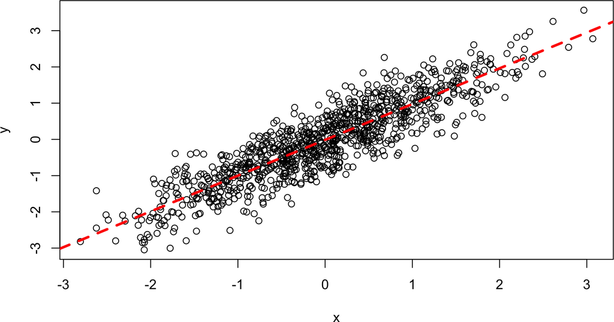

```r
plot(y ~ x, df)                      # methods(plot); ?plot.formula
abline(fit, col="red", lwd=3, lty=2) # a function, not generic.method
```

Use `methods()` for introspection 9calss and method discovery), e.g.,

```r
methods(class=class(fit))            # introspection
```

```
##  [1] add1           alias          anova          case.names     coerce
##  [6] confint        cooks.distance deviance       dfbeta         dfbetas
## [11] drop1          dummy.coef     effects        extractAIC     family
## [16] formula        hatvalues      influence      initialize     kappa
## [21] labels         logLik         model.frame    model.matrix   nobs
## [26] plot           predict        print          proj           qr
## [31] residuals      rstandard      rstudent       show           simulate
## [36] slotsFromS3    summary        variable.names vcov
## see '?methods' for accessing help and source code
```

## 2.2 GO (gene ontology) identifiers

Programming example – group 1000 gene SYMBOLs into GO identifiers

The file ‘symgo.csv’ is from an Excel spreadsheet (exported as ‘csv’ – comma-separated value – format) with four columns – the gene ‘SYMBOL’ (e.g., `SOX17`), the gene ontology (GO) term(s) that the symbol has been associated with, and additional gene ontology information.

```r
## example data
fl <- file.choose()      ## symgo.csv
```

```r
symgo <- read.csv(fl, row.names=1, stringsAsFactors=FALSE)
head(symgo)
```

```
##      SYMBOL         GO EVIDENCE ONTOLOGY
## 1   PPIAP28       <NA>     <NA>     <NA>
## 2     PTLAH       <NA>     <NA>     <NA>
## 3 HIST1H2BC GO:0000786      NAS       CC
## 4 HIST1H2BC GO:0000788      IBA       CC
## 5 HIST1H2BC GO:0002227      IDA       BP
## 6 HIST1H2BC GO:0003677      IBA       MF
```

```r
dim(symgo)
```

```
## [1] 5041    4
```

```r
length(unique(symgo$SYMBOL))
```

```
## [1] 1000
```

```r
head(symgo[symgo$SYMBOL == "SOX17",])
```

```
##      SYMBOL         GO EVIDENCE ONTOLOGY
## 4576  SOX17 GO:0000122      IEA       BP
## 4577  SOX17 GO:0001525      ISS       BP
## 4578  SOX17 GO:0001570      ISS       BP
## 4579  SOX17 GO:0001706      IDA       BP
## 4580  SOX17 GO:0001828      IEA       BP
## 4581  SOX17 GO:0001947      ISS       BP
```

How many gene SYMBOLs are associated with each GO term? There are several ways to calculate this…

```r
## split + length
go2sym <- split(symgo$SYMBOL, symgo$GO)
len1 <- lengths(go2sym)
head(len1)
```

```
## GO:0000049 GO:0000050 GO:0000060 GO:0000077 GO:0000086 GO:0000118
##          3          2          1          1          3          1
```

```r
## smarter built-in functions, e.g., omiting NAs
len2 <- aggregate(SYMBOL ~ GO, symgo, length)
head(len1)
```

```
## GO:0000049 GO:0000050 GO:0000060 GO:0000077 GO:0000086 GO:0000118
##          3          2          1          1          3          1
```

In `aggregate()`, the third argument is `FUN`. The value of `FUN` is the function that is applied to each group defined by the formula of the first argument. Provide a ‘custom’ function that uses the unique lower-case values

```r
## your own function -- unique, lower-case identifiers
uidfun  <- function(x)
    unique(tolower(x))
```

This illustrates how one is not restricted to ‘built-in’ solutions for solving biological problems.

```r
head(aggregate(SYMBOL ~ GO , symgo, uidfun))
```

```
##           GO                SYMBOL
## 1 GO:0000049         yars2, eef1a1
## 2 GO:0000050                   asl
## 3 GO:0000060                 oprd1
## 4 GO:0000077                 pea15
## 5 GO:0000086 tubb4a, cenpf, clasp1
## 6 GO:0000118                  cir1
```

# 3 Case studies

These case studies serve as refreshers on *R* input and manipulation of data.

## 3.1 ALL phenotypic data

Input a file that contains ALL (acute lymphoblastic leukemia) patient information

```r
fname <- file.choose()   ## "ALLphenoData.tsv"
stopifnot(file.exists(fname))
pdata <- read.delim(fname)
```

Check out the help page `?read.delim` for input options, and explore basic properties of the object you’ve created, for instance…

```r
class(pdata)
```

```
## [1] "data.frame"
```

```r
colnames(pdata)
```

```
##  [1] "id"             "diagnosis"      "sex"            "age"
##  [5] "BT"             "remission"      "CR"             "date.cr"
##  [9] "t.4.11."        "t.9.22."        "cyto.normal"    "citog"
## [13] "mol.biol"       "fusion.protein" "mdr"            "kinet"
## [17] "ccr"            "relapse"        "transplant"     "f.u"
## [21] "date.last.seen"
```

```r
dim(pdata)
```

```
## [1] 127  21
```

```r
head(pdata)
```

```
##     id diagnosis sex age BT remission CR   date.cr t.4.11. t.9.22. cyto.normal
## 1 1005 5/21/1997   M  53 B2        CR CR  8/6/1997   FALSE    TRUE       FALSE
## 2 1010 3/29/2000   M  19 B2        CR CR 6/27/2000   FALSE   FALSE       FALSE
## 3 3002 6/24/1998   F  52 B4        CR CR 8/17/1998      NA      NA          NA
## 4 4006 7/17/1997   M  38 B1        CR CR  9/8/1997    TRUE   FALSE       FALSE
## 5 4007 7/22/1997   M  57 B2        CR CR 9/17/1997   FALSE   FALSE       FALSE
## 6 4008 7/30/1997   M  17 B1        CR CR 9/27/1997   FALSE   FALSE       FALSE
##          citog mol.biol fusion.protein mdr   kinet   ccr relapse transplant
## 1      t(9;22)  BCR/ABL           p210 NEG dyploid FALSE   FALSE       TRUE
## 2  simple alt.      NEG           <NA> POS dyploid FALSE    TRUE      FALSE
## 3         <NA>  BCR/ABL           p190 NEG dyploid FALSE    TRUE      FALSE
## 4      t(4;11) ALL1/AF4           <NA> NEG dyploid FALSE    TRUE      FALSE
## 5      del(6q)      NEG           <NA> NEG dyploid FALSE    TRUE      FALSE
## 6 complex alt.      NEG           <NA> NEG hyperd. FALSE    TRUE      FALSE
##                 f.u date.last.seen
## 1 BMT / DEATH IN CR           <NA>
## 2               REL      8/28/2000
## 3               REL     10/15/1999
## 4               REL      1/23/1998
## 5               REL      11/4/1997
## 6               REL     12/15/1997
```

```r
summary(pdata$sex)
```

```
##    Length     Class      Mode
##       127 character character
```

```r
summary(pdata$cyto.normal)
```

```
##    Mode   FALSE    TRUE    NA's
## logical      69      24      34
```

Remind yourselves about various ways to subset and access columns of a data.frame

```r
pdata[1:5, 3:4]
```

```
##   sex age
## 1   M  53
## 2   M  19
## 3   F  52
## 4   M  38
## 5   M  57
```

```r
pdata[1:5, ]
```

```
##     id diagnosis sex age BT remission CR   date.cr t.4.11. t.9.22. cyto.normal
## 1 1005 5/21/1997   M  53 B2        CR CR  8/6/1997   FALSE    TRUE       FALSE
## 2 1010 3/29/2000   M  19 B2        CR CR 6/27/2000   FALSE   FALSE       FALSE
## 3 3002 6/24/1998   F  52 B4        CR CR 8/17/1998      NA      NA          NA
## 4 4006 7/17/1997   M  38 B1        CR CR  9/8/1997    TRUE   FALSE       FALSE
## 5 4007 7/22/1997   M  57 B2        CR CR 9/17/1997   FALSE   FALSE       FALSE
##         citog mol.biol fusion.protein mdr   kinet   ccr relapse transplant
## 1     t(9;22)  BCR/ABL           p210 NEG dyploid FALSE   FALSE       TRUE
## 2 simple alt.      NEG           <NA> POS dyploid FALSE    TRUE      FALSE
## 3        <NA>  BCR/ABL           p190 NEG dyploid FALSE    TRUE      FALSE
## 4     t(4;11) ALL1/AF4           <NA> NEG dyploid FALSE    TRUE      FALSE
## 5     del(6q)      NEG           <NA> NEG dyploid FALSE    TRUE      FALSE
##                 f.u date.last.seen
## 1 BMT / DEATH IN CR           <NA>
## 2               REL      8/28/2000
## 3               REL     10/15/1999
## 4               REL      1/23/1998
## 5               REL      11/4/1997
```

```r
head(pdata[, 3:5])
```

```
##   sex age BT
## 1   M  53 B2
## 2   M  19 B2
## 3   F  52 B4
## 4   M  38 B1
## 5   M  57 B2
## 6   M  17 B1
```

```r
tail(pdata[, 3:5], 3)
```

```
##     sex age BT
## 125   M  19 T2
## 126   M  30 T3
## 127   M  29 T2
```

```r
head(pdata$age)
```

```
## [1] 53 19 52 38 57 17
```

```r
head(pdata$sex)
```

```
## [1] "M" "M" "F" "M" "M" "M"
```

```r
head(pdata[pdata$age > 21,])
```

```
##      id diagnosis sex age BT remission CR   date.cr t.4.11. t.9.22. cyto.normal
## 1  1005 5/21/1997   M  53 B2        CR CR  8/6/1997   FALSE    TRUE       FALSE
## 3  3002 6/24/1998   F  52 B4        CR CR 8/17/1998      NA      NA          NA
## 4  4006 7/17/1997   M  38 B1        CR CR  9/8/1997    TRUE   FALSE       FALSE
## 5  4007 7/22/1997   M  57 B2        CR CR 9/17/1997   FALSE   FALSE       FALSE
## 10 8001 1/15/1997   M  40 B2        CR CR 3/26/1997   FALSE   FALSE       FALSE
## 11 8011 8/21/1998   M  33 B3        CR CR 10/8/1998   FALSE   FALSE       FALSE
##           citog mol.biol fusion.protein mdr   kinet   ccr relapse transplant
## 1       t(9;22)  BCR/ABL           p210 NEG dyploid FALSE   FALSE       TRUE
## 3          <NA>  BCR/ABL           p190 NEG dyploid FALSE    TRUE      FALSE
## 4       t(4;11) ALL1/AF4           <NA> NEG dyploid FALSE    TRUE      FALSE
## 5       del(6q)      NEG           <NA> NEG dyploid FALSE    TRUE      FALSE
## 10     del(p15)  BCR/ABL           p190 NEG    <NA> FALSE    TRUE      FALSE
## 11 del(p15/p16)  BCR/ABL      p190/p210 NEG dyploid FALSE   FALSE       TRUE
##                  f.u date.last.seen
## 1  BMT / DEATH IN CR           <NA>
## 3                REL     10/15/1999
## 4                REL      1/23/1998
## 5                REL      11/4/1997
## 10               REL      7/11/1997
## 11 BMT / DEATH IN CR           <NA>
```

It seems from below that there are 17 females over 40 in the data set, but when sub-setting `pdata` to contain just those individuals 19 rows are selected. Why? What can we do to correct this?

```r
idx <- pdata$sex == "F" & pdata$age > 40
table(idx)
```

```
## idx
## FALSE  TRUE
##   108    17
```

```r
dim(pdata[idx,])
```

```
## [1] 19 21
```

Use the `mol.biol` column to subset the data to contain just individuals with ‘BCR/ABL’ or ‘NEG’, e.g.,

```r
bcrabl <- pdata[pdata$mol.biol %in% c("BCR/ABL", "NEG"),]
```

The `mol.biol` column is a factor, and retains all levels even after subsetting. How might you drop the unused factor levels?

```r
bcrabl$mol.biol <- factor(bcrabl$mol.biol)
```

The `BT` column is a factor describing B- and T-cell subtypes

```r
levels(bcrabl$BT)
```

How might one collapse B1, B2, … to a single type B, and likewise for T1, T2, …, so there are only two subtypes, B and T

```r
table(bcrabl$BT)
```

```
##
##  B B1 B2 B3 B4  T T1 T2 T3 T4
##  4  9 35 22  9  4  1 15  9  2
```

```r
levels(bcrabl$BT) <- substring(levels(bcrabl$BT), 1, 1)
table(bcrabl$BT)
```

[output not shown]

Use `xtabs()` (cross-tabulation) to count the number of samples with B- and T-cell types in each of the BCR/ABL and NEG groups

```r
xtabs(~ BT + mol.biol, bcrabl)
```

```
##     mol.biol
## BT   BCR/ABL NEG
##   B        2   2
##   B1       1   8
##   B2      19  16
##   B3       8  14
##   B4       7   2
##   T        0   4
##   T1       0   1
##   T2       0  15
##   T3       0   9
##   T4       0   2
```

Use `aggregate()` to calculate the average age of males and females in the BCR/ABL and NEG treatment groups.

```r
aggregate(age ~ mol.biol + sex, bcrabl, mean)
```

```
##   mol.biol sex      age
## 1  BCR/ABL   F 39.93750
## 2      NEG   F 30.42105
## 3  BCR/ABL   M 40.50000
## 4      NEG   M 27.21154
```

Use `t.test()` to compare the age of individuals in the BCR/ABL versus NEG groups; visualize the results using `boxplot()`. In both cases, use the `formula` interface. Consult the help page `?t.test` and re-do the test assuming that variance of ages in the two groups is identical. What parts of the test output change?

```r
t.test(age ~ mol.biol, bcrabl)
```

```
##
##  Welch Two Sample t-test
##
## data:  age by mol.biol
## t = 4.8172, df = 68.529, p-value = 8.401e-06
## alternative hypothesis: true difference in means between group BCR/ABL and group NEG is not equal to 0
## 95 percent confidence interval:
##   7.13507 17.22408
## sample estimates:
## mean in group BCR/ABL     mean in group NEG
##              40.25000              28.07042
```

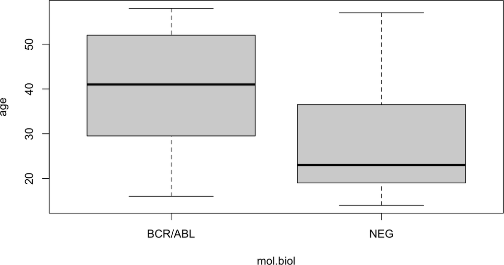

```r
boxplot(age ~ mol.biol, bcrabl)
```

## 3.2 Weighty matters

This case study is a second walk through basic data manipulation and visualization skills. We use data from the US Center for Disease Control’s Behavioral Risk Factor Surveillance System ([BRFSS](http://www.cdc.gov/brfss/)) annual survey. Check out the web page for a little more information. We are using a small subset of this data, including a random sample of 10000 observations from each of 1990 and 2010.

Input the data using `read.csv()`, creating a variable `brfss` to hold it. Use `file.choose()` to locate the data file BRFSS-subset.csv

```r
fname <- file.choose()   ## BRFSS-subset.csv
stopifnot(file.exists(fname))
brfss <- read.csv(fname)
```

**Base plotting functions**

1. Explore the data using `class()`, `dim()`, `head()`, `summary()`, etc. Use `xtabs()` to summarize the number of males and females in the study, in each of the two years.
2. Use `aggregate()` to summarize the average weight in each sex and year.
3. Create a scatterplot showing the relationship between the square root of weight and height, using the `plot()` function and the `main` argument to annotate the plot. Note the transformed Y-axis. Experiment with different plotting symbols (try the command `example(points)` to view different points).

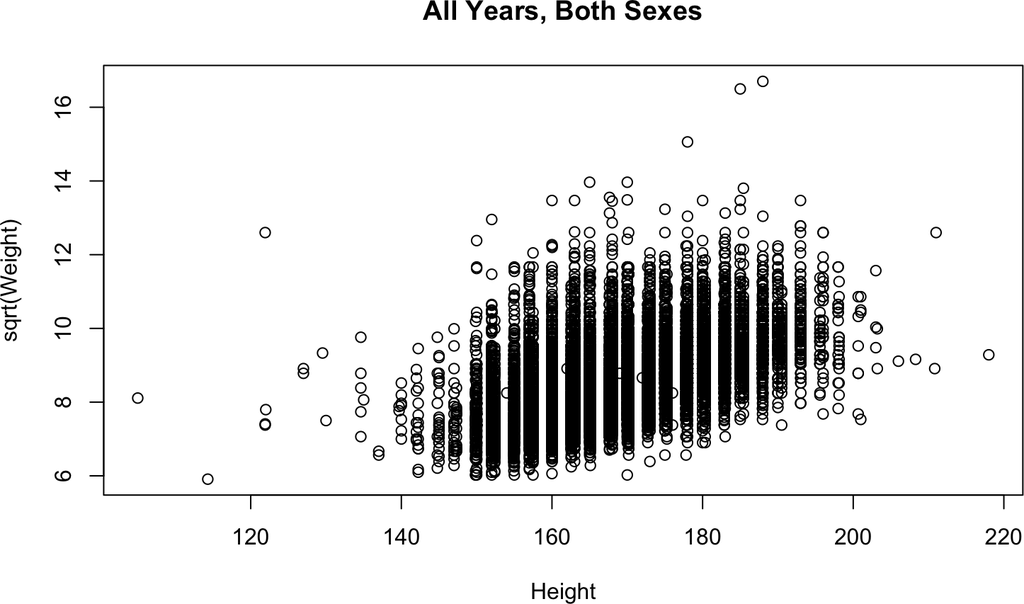

   ```r
   plot(sqrt(Weight) ~ Height, brfss, main="All Years, Both Sexes")
   ```

   ```r
   brfss2010 <- brfss[brfss$Year == "2010", ]
   ```

6. Create the figure below (two panels in a single figure). Do this by using the `par()` function with the `mfcol` argument before calling `plot()`. You’ll need to create two more subsets of data, perhaps when you are providing the data to the function `plot`.

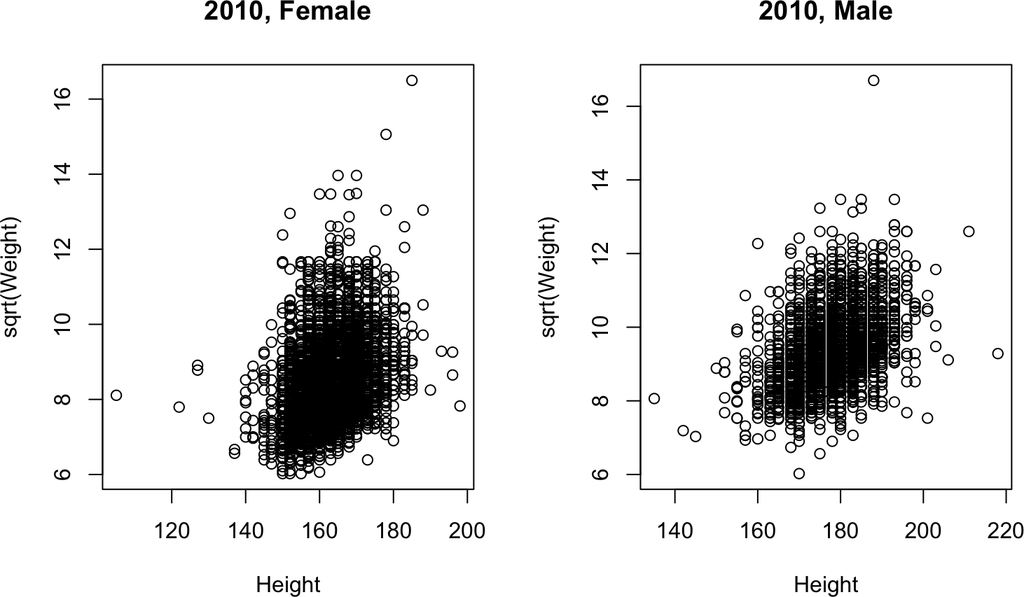

   ```r
   opar <- par(mfcol=c(1, 2))
   plot(sqrt(Weight) ~ Height, brfss2010[brfss2010$Sex == "Female", ],
        main="2010, Female")
   plot(sqrt(Weight) ~ Height, brfss2010[brfss2010$Sex == "Male", ],
        main="2010, Male")
   ```

   ```r
   par(opar)                           # reset 'par' to original value
   ```

7. Plotting large numbers of points means that they are often over-plotted, potentially obscuring important patterns. Experiment with arguments to `plot()` to address over-plotting, e.g., `pch='.'` or `alpha=.4`. Try using the `smoothScatter()` function (the data have to be presented as `x` and `y`, rather than as a formula). Try adding the hexbin library to your R session (using `library()`) and creating a `hexbinplot()`.

**ggplot2 graphics**

1. Create a scatterplot showing the relationship between the square root of weight and height, using the *ggplot2* library, and the annotate the plot. Two equivalent ways to create the plot are show in the solution.

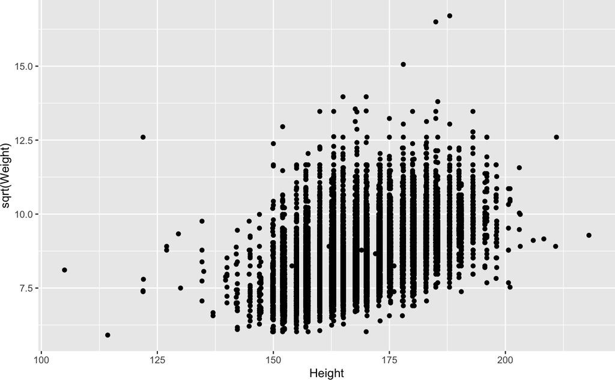

   ## 'quick' plot
   qplot(Height, sqrt(Weight), data=brfss)
   ```

   ```
   ## Warning: Removed 735 rows containing missing values (`geom_point()`).
   ```

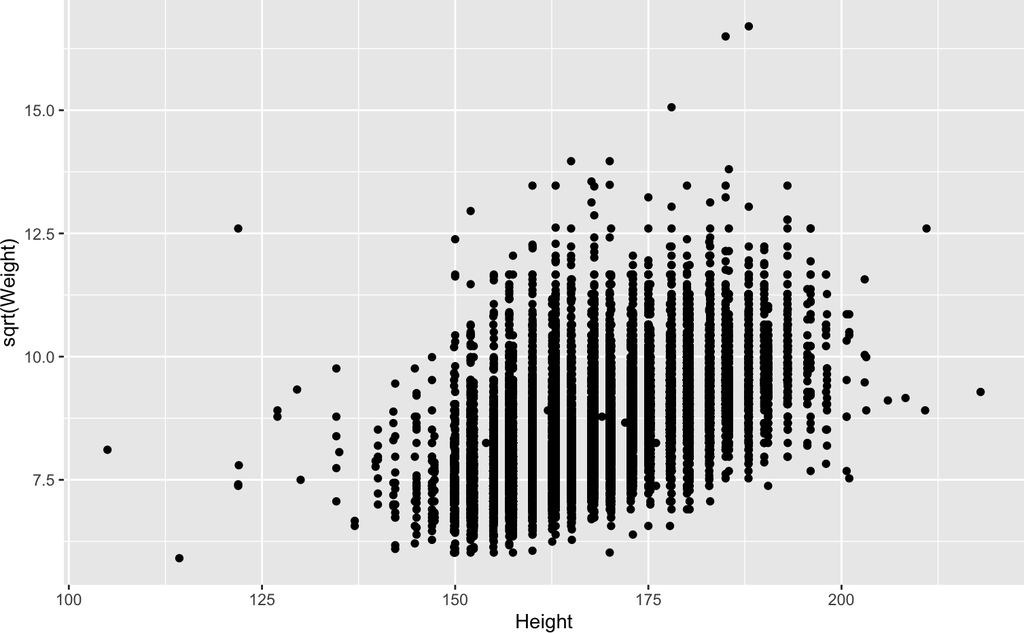

   ```r
   ## specify the data set and 'aesthetics', then how to plot
   ggplot(brfss, aes(x=Height, y=sqrt(Weight))) +
       geom_point()
   ```

   `qplot()` gives us a warning which states that it has removed rows containing missing values. This is actually very helpful because we find out that our dataset contains `NA`’s and we can take a design decision here about what we’d like to do these `NA`’s. We can find the indicies of the rows containing `NA` using `is.na()`, and count the number of rows with `NA` values using `sum()`:

   ```r
   sum(is.na(brfss$Height))
   ```

   ```
   ## [1] 184
   ```

   ```r
   sum(is.na(brfss$Weight))
   ```

   ```
   ## [1] 649
   ```

   ```r
   drop <- is.na(brfss$Height) | is.na(brfss$Weight)
   sum(drop)
   ```

   ```
   ## [1] 735
   ```

   Remove the rows which contain `NA`’s in Height and Weight.

   ```r
   brfss <- brfss[!drop,]
   ```

   Plot is annotated with

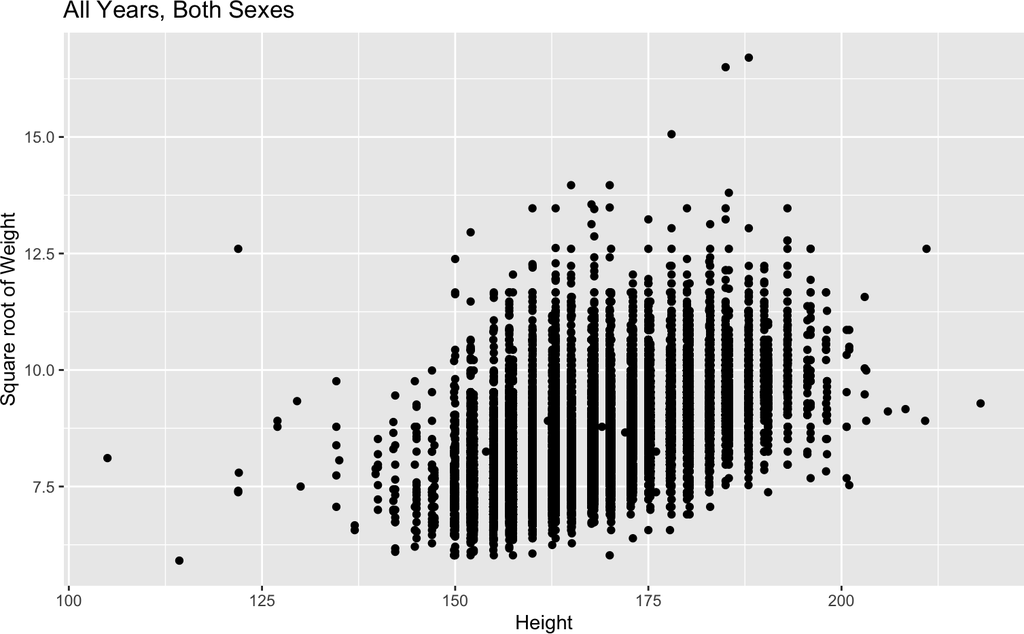

   ```r
   qplot(Height, sqrt(Weight), data=brfss) +
       ylab("Square root of Weight") +
           ggtitle("All Years, Both Sexes")
   ```

2. Color the female and male points differently.

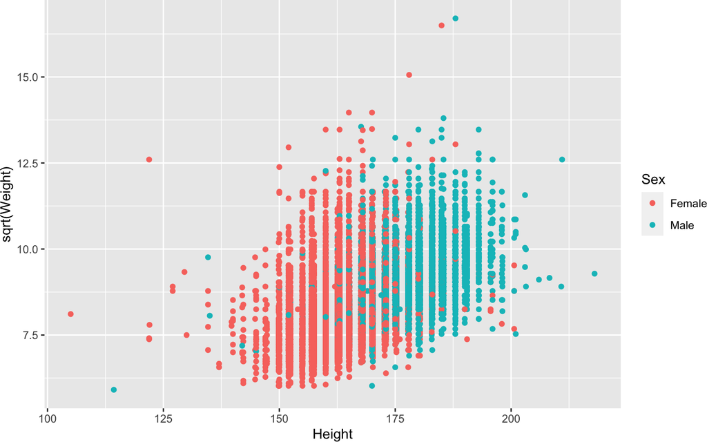

   ```r
   ggplot(brfss, aes(x=Height, y=sqrt(Weight), color=Sex)) +
       geom_point()
   ```

   One can also change the shape of the points for the female and male groups

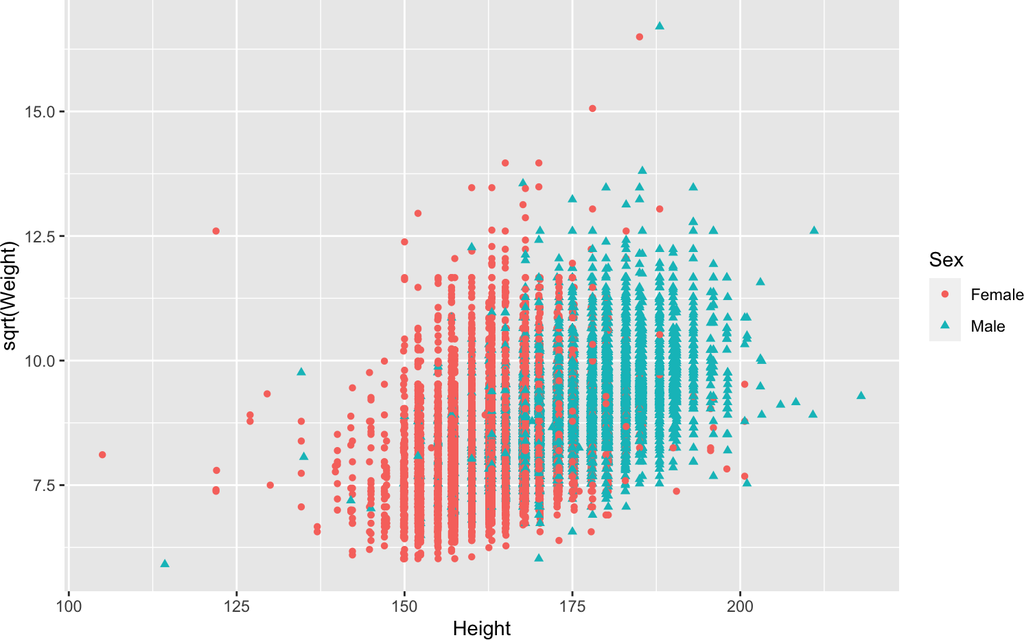

   ```r
   ggplot(brfss, aes(x=Height, y = sqrt(Weight), color=Sex, shape=Sex)) +
       geom_point()
   ```

   or plot Male and Female in different panels using `facet_grid()`

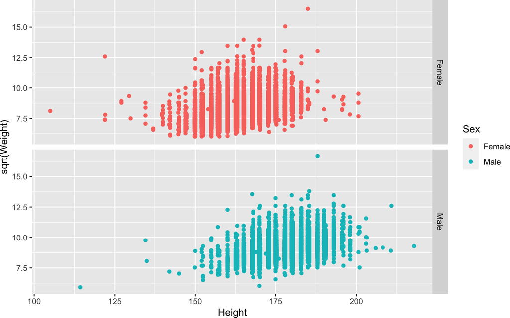

   ```r
   ggplot(brfss, aes(x=Height, y = sqrt(Weight), color=Sex)) +
       geom_point() +
           facet_grid(Sex ~ .)
   ```

3. Create a subset of the data containing only observations from 2010 and make density curves for male and female groups. Use the `fill` aesthetic to indicate that each sex is to be calculated separately, and `geom_density()` for the density plot.

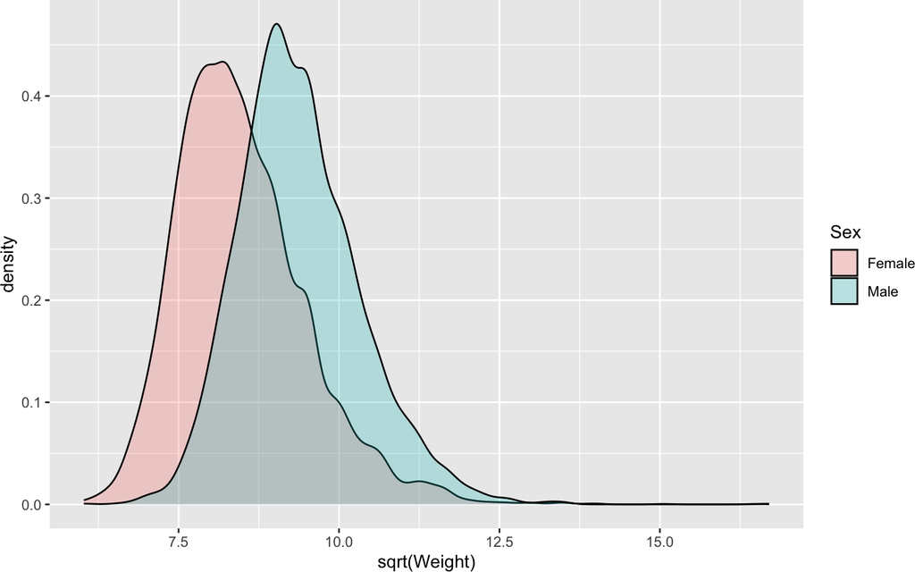

   ```r
   brfss2010 <- brfss[brfss$Year == "2010", ]
   ggplot(brfss2010, aes(x=sqrt(Weight), fill=Sex)) +
       geom_density(alpha=.25)
   ```

4. Plotting large numbers of points means that they are often over-plotted, potentially obscuring important patterns. Make the points semi-transparent using alpha. Here we make them 60% transparent. The solution illustrates a nice feature of ggplot2 – a partially specified plot can be assigned to a variable, and the variable modified at a later point.

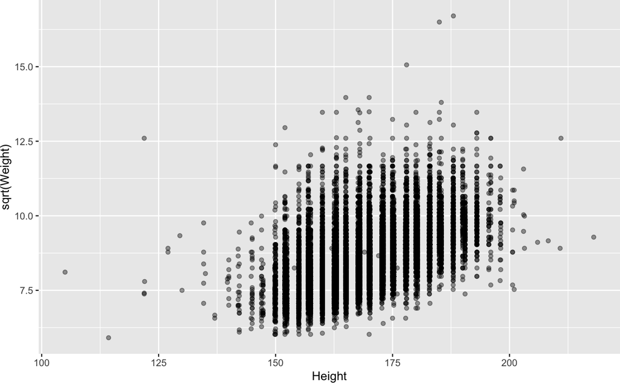

   ```r
   sp <- ggplot(brfss, aes(x=Height, y=sqrt(Weight)))
   sp + geom_point(alpha=.4)
   ```

5. Add a fitted regression model to the scatter plot.

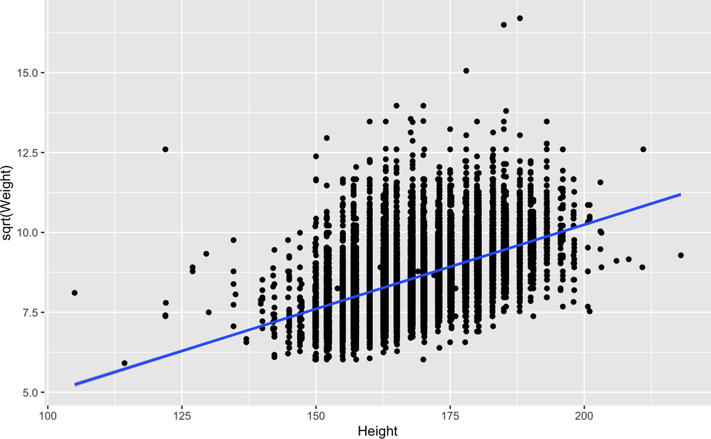

   ```r
   sp + geom_point() + stat_smooth(method=lm)
   ```

   By default, `stat_smooth()` also adds a 95% confidence region for the regression fit. The confidence interval can be changed by setting level, or it can be disabled with `se=FALSE`.

6. How do you fit a linear regression line for each group? First we’ll make the base plot object sps, then we’ll add the linear regression lines to it.

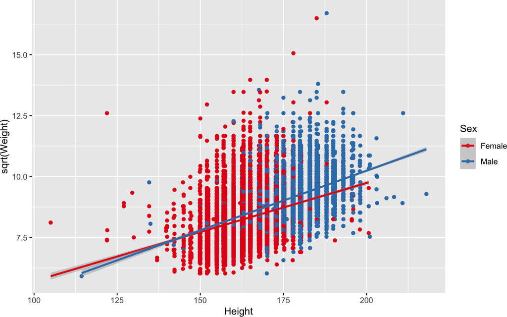

   ```r
   sps <- ggplot(brfss, aes(x=Height, y=sqrt(Weight), colour=Sex)) +
       geom_point() +
           scale_colour_brewer(palette="Set1")
   sps + geom_smooth(method="lm")
   ```

# 4 End matter

## 4.2 Acknowledgements

Research reported in this tutorial was supported by the National Human Genome Research Institute and the National Cancer Institute of the National Institutes of Health under award numbers U24HG004059 (Bioconductor), U24HG010263 (AnVIL) and U24CA180996 (ITCR).